# Project 3 Data Summaries

Benjamin Goldstone

April 12th, 2023

# Collection Method and Description

Using a ball and a bucket both of us did 20 trials with different hands and angles based on a random number from a random number generator to see if there is evidence that one way of throwing a ball is dominant. Each hand/angle combination was assigned a number from 1-4.

1. Left Over
2. Right Over
3. Left Under
4. Right Under

# Variables

Response: Make or Miss Explanatory: Overhand/Underhand and Right Hand/Left Hand

```r
library(readr)
DataCollectionProject3 <- read_csv("~/Projects/Project 3/DataCollectionProject3.csv")
head(DataCollectionProject3)
```

```
## # A tibble: 6 × 4
##   TrialNumber LeftRight OverUnder MakeMiss
##         <dbl> <chr>     <chr>     <chr>
## 1           1 Right     Under     Miss
## 2           2 Left      Over      Miss
## 3           3 Right     Under     Miss
## 4           4 Left      Over      Miss
## 5           5 Left      Under     Miss
## 6           6 Right     Under     Miss
```

# Hypotheses

H0: pi_left = pi_right

Ha: pi_left < pi_right

# Graphs

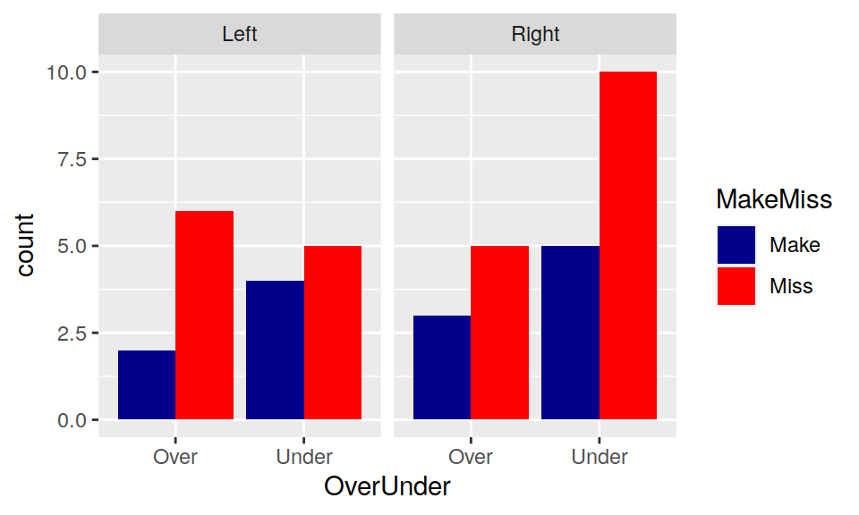

```r
gf_bar(~OverUnder|LeftRight, fill=~MakeMiss, data=DataCollectionProject3, position=position_dodge( ))%>%
gf_refine(scale_fill_manual(values = c("darkblue","red")))
```

When throwing a ball into a basket, the right hand seems to make it into the basket more than the left hand.

In addition, when using underhand we made more baskets than when we used overhand.

# Proportion Test

```r
tally(MakeMiss~LeftRight, data=DataCollectionProject3)
```

```
##         LeftRight
## MakeMiss Left Right
##     Make    6     8
##     Miss   11    15
```

```r
prop.test(c(6,8),c(17,23),alternative = "less", conf.level = 0.9)
```

```
##
##  2-sample test for equality of proportions with continuity correction
##
## data:  c out of c6 out of 178 out of 23
## X-squared = 4.0711e-31, df = 1, p-value = 0.5
## alternative hypothesis: less
## 90 percent confidence interval:
##  -1.0000000  0.2058358
## sample estimates:
##    prop 1    prop 2
## 0.3529412 0.3478261
```

# Conclusion

Given a 90% confidence interval, we fail to reject the null hypothesis, due to 0 being included in the interval. With 0 being in the interval, it shows the null hypothesis to be a possibility.

We can conclude that there is a no significant difference between what hand you throw a ball with to make a shot.